## Homework Involvement (15 items)

Please indicate how often you have done the following to help your child with homework in the past three months…

84 I made sure they had a set time to do their homework.

85 I made sure they had a set place to do their homework.

86 I sat with my child while they did their homework.

87 I made myself available when my child had questions about their homework.

88 I helped my child when they were stuck on an assignment.

89 I helped my child prepare for exams by asking questions about the topic, etc.

90 I gave my child incentives like special privileges or gifts.

91 I used consequences, punishment, or disciplinary actions.

92 I reminded my child to do their homework.

93 I checked in with my child to make sure they did their homework.

94 I checked and corrected my child’s homework.

95 I checked with the teacher to make sure my child completed their homework.

96 I helped my child access other resources (library, art materials, computer lab, etc.).

97 I helped my child practice skills (reading, reviewing, practice problems, etc.).

98 I limited noise and/or distractions while they did their homework.

```r
hw_inv <- parent_w1 %>%
  select(q84, q85, q86, q87, q88, q89, q90, q91, q92, q93, q94, q95, q96, q97, q98)
```

### Kaiser-Meyer-Olkin factor sampling adequacy (> 0.5)

```r
KMO(hw_inv)
```

```
## Kaiser-Meyer-Olkin factor adequacy
## Call: KMO(r = hw_inv)
## Overall MSA =  0.71
## MSA for each item =
##  q84  q85  q86  q87  q88  q89  q90  q91  q92  q93  q94  q95  q96  q97  q98
## 0.61 0.64 0.84 0.72 0.73 0.81 0.64 0.52 0.50 0.74 0.75 0.76 0.82 0.66 0.73
```

### Bartlett’s Test of Sphericity (p < .05)

```r
poly <- polychoric(hw_inv)$rho
cortest.bartlett(poly, n = nrow(hw_inv))
```

```
## $chisq
## [1] 873.7286
##
## $p.value
## [1] 0.0000000000000000000000000000000000000000000000000000000000000000000000000000000000000000000000000000000000000000000000001806383
##
## $df
## [1] 105
```

### Poly corr matrix

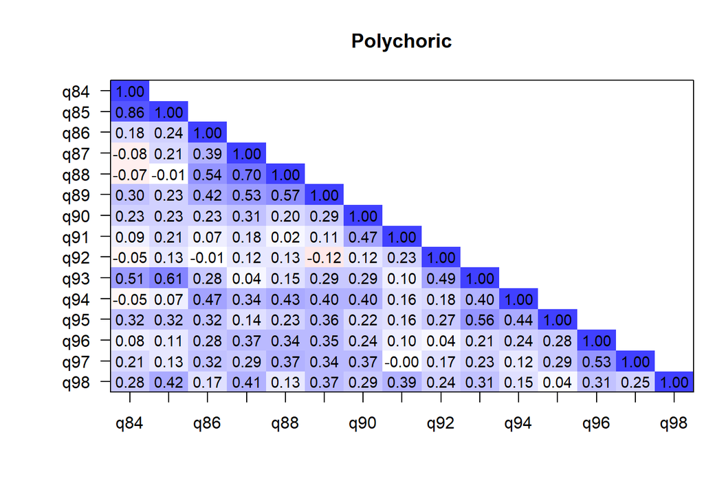

```r
cor.plot(poly, numbers = T, upper = F, main = "Polychoric", show.legend = F)
```

### Scree plot

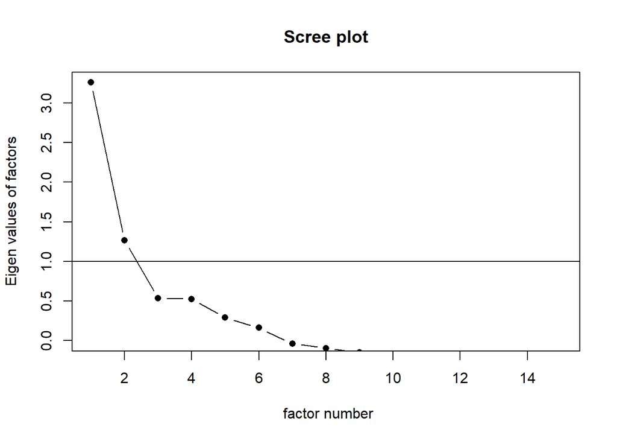

```r
scree(hw_inv, factors = TRUE, pc = FALSE, main = "Scree plot", hline = NULL, add = FALSE)
```

### Removing items with very low correlations

```r
hw_inv <- parent_w1 %>%
  select(q84, q85, q86, q87, q88, q89, q90, q93, q94, q95, q96, q97, q98) # removing 91 and 92
```

### Kaiser-Meyer-Olkin factor sampling adequacy (> 0.5)

```r
KMO(hw_inv)
```

```
## Kaiser-Meyer-Olkin factor adequacy
## Call: KMO(r = hw_inv)
## Overall MSA =  0.74
## MSA for each item =
##  q84  q85  q86  q87  q88  q89  q90  q93  q94  q95  q96  q97  q98
## 0.61 0.63 0.88 0.71 0.72 0.86 0.73 0.79 0.75 0.78 0.84 0.75 0.76
```

### Bartlett’s Test of Sphericity (p < .05)

```r
poly <- polychoric(hw_inv)$rho
cortest.bartlett(poly, n = nrow(hw_inv))
```

```
## $chisq
## [1] 724.9254
##
## $p.value
## [1] 0.000000000000000000000000000000000000000000000000000000000000000000000000000000000000000000000000000000001465132
##
## $df
## [1] 78
```

### Poly corr matrix

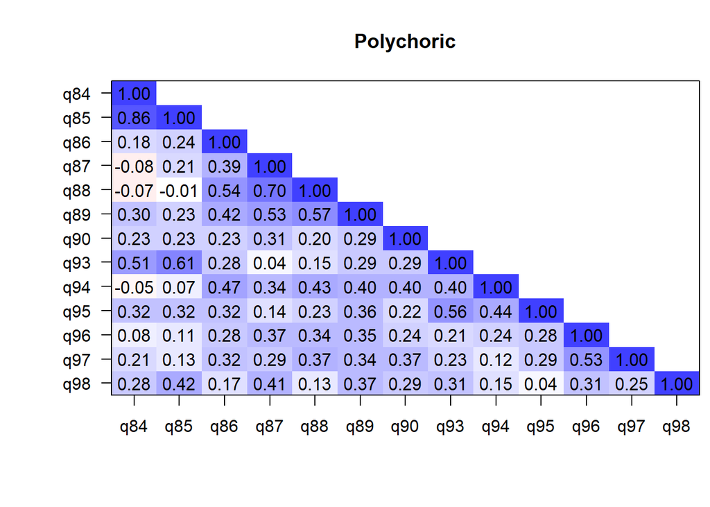

```r
cor.plot(poly, numbers = T, upper = F, main = "Polychoric", show.legend = F)
```

### Scree plot

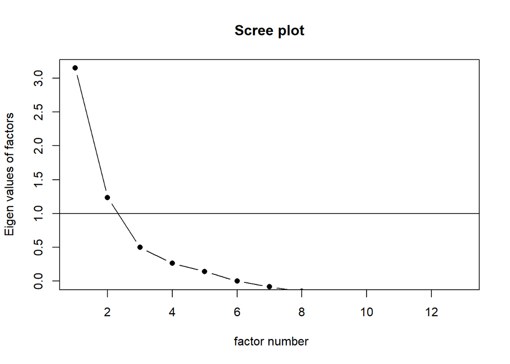

```r
scree(hw_inv, factors = TRUE, pc = FALSE, main = "Scree plot", hline = NULL, add = FALSE)
```

### EFA using ULS 2 factors

```r
factor_test_uls <- fa(hw_inv, n.obs = 95, rotate = "oblimin", fm = "uls", cor = "poly", nfactors = 2)
factor_test_uls
```

```
## Factor Analysis using method =  uls
## Call: fa(r = hw_inv, nfactors = 2, n.obs = 95, rotate = "oblimin",
##     fm = "uls", cor = "poly")
## Standardized loadings (pattern matrix) based upon correlation matrix
##      ULS1  ULS2   h2   u2 com
## q84 -0.11  0.91 0.81 0.19 1.0
## q85  0.01  0.90 0.81 0.19 1.0
## q86  0.59  0.13 0.39 0.61 1.1
## q87  0.74 -0.08 0.53 0.47 1.0
## q88  0.84 -0.18 0.69 0.31 1.1
## q89  0.66  0.19 0.51 0.49 1.2
## q90  0.39  0.23 0.23 0.77 1.6
## q93  0.22  0.65 0.51 0.49 1.2
## q94  0.57  0.06 0.34 0.66 1.0
## q95  0.34  0.37 0.30 0.70 2.0
## q96  0.51  0.09 0.29 0.71 1.1
## q97  0.48  0.15 0.28 0.72 1.2
## q98  0.30  0.32 0.23 0.77 2.0
##
##                       ULS1 ULS2
## SS loadings           3.34 2.56
## Proportion Var        0.26 0.20
## Cumulative Var        0.26 0.45
## Proportion Explained  0.57 0.43
## Cumulative Proportion 0.57 1.00
##
##  With factor correlations of
##      ULS1 ULS2
## ULS1 1.00 0.17
## ULS2 0.17 1.00
##
## Mean item complexity =  1.3
## Test of the hypothesis that 2 factors are sufficient.
##
## df null model =  78  with the objective function =  8.16 with Chi Square =  724.93
## df of  the model are 53  and the objective function was  3.36
##
## The root mean square of the residuals (RMSR) is  0.09
## The df corrected root mean square of the residuals is  0.11
##
## The harmonic n.obs is  93 with the empirical chi square  109.07  with prob <  0.0000093
## The total n.obs was  95  with Likelihood Chi Square =  294.32  with prob <  0.000000000000000000000000000000000036
##
## Tucker Lewis Index of factoring reliability =  0.442
## RMSEA index =  0.219  and the 90 % confidence intervals are  0.196 0.245
## BIC =  52.96
## Fit based upon off diagonal values = 0.93
## Measures of factor score adequacy
##                                                   ULS1 ULS2
## Correlation of (regression) scores with factors   0.93 0.96
## Multiple R square of scores with factors          0.87 0.91
## Minimum correlation of possible factor scores     0.74 0.82
```

### Removing crossloading items

```r
hw_inv <- parent_w1 %>%
  select(q84, q85, q86, q87, q88, q89, q93, q94, q96, q97) # removing 90, 95, and 98
```

### Kaiser-Meyer-Olkin factor sampling adequacy (> 0.5)

```r
KMO(hw_inv)
```

```
## Kaiser-Meyer-Olkin factor adequacy
## Call: KMO(r = hw_inv)
## Overall MSA =  0.73
## MSA for each item =
##  q84  q85  q86  q87  q88  q89  q93  q94  q96  q97
## 0.58 0.59 0.85 0.72 0.76 0.84 0.76 0.76 0.78 0.77
```

### Bartlett’s Test of Sphericity (p < .05)

```r
poly <- polychoric(hw_inv)$rho
cortest.bartlett(poly, n = nrow(hw_inv))
```

```
## $chisq
## [1] 572.6151
##
## $p.value
## [1] 0.00000000000000000000000000000000000000000000000000000000000000000000000000000000000000000001370273
##
## $df
## [1] 45
```

### Poly corr matrix

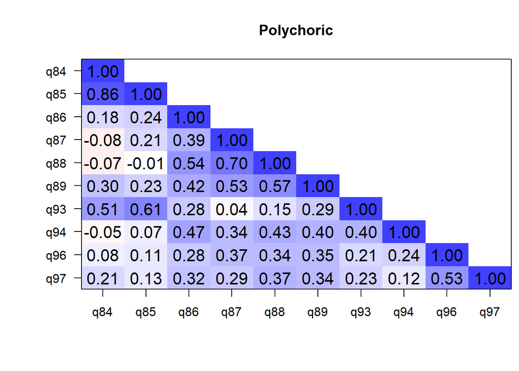

```r
cor.plot(poly, numbers = T, upper = F, main = "Polychoric", show.legend = F)
```

### Scree plot

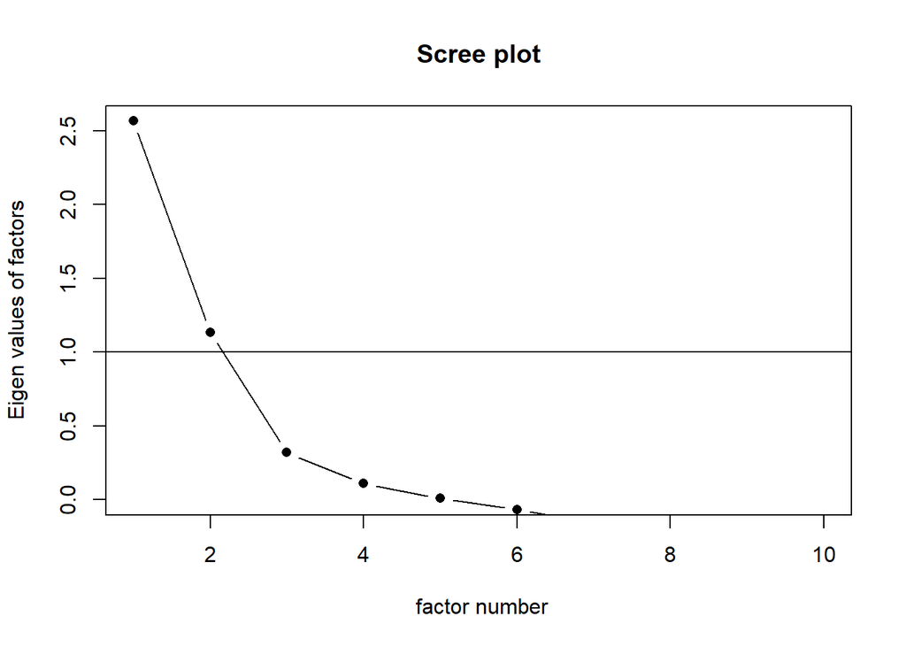

```r
scree(hw_inv, factors = TRUE, pc = FALSE, main = "Scree plot", hline = NULL, add = FALSE)
```

### 2nd EFA iteration

```r
factor_test_uls <- fa(hw_inv, n.obs = 95, rotate = "oblimin", fm = "uls", cor = "poly", nfactors = 2)
factor_test_uls
```

```
## Factor Analysis using method =  uls
## Call: fa(r = hw_inv, nfactors = 2, n.obs = 95, rotate = "oblimin",
##     fm = "uls", cor = "poly")
## Standardized loadings (pattern matrix) based upon correlation matrix
##      ULS1  ULS2   h2   u2 com
## q84 -0.08  0.95 0.89 0.11 1.0
## q85  0.04  0.90 0.83 0.17 1.0
## q86  0.60  0.16 0.42 0.58 1.1
## q87  0.73 -0.06 0.52 0.48 1.0
## q88  0.88 -0.14 0.76 0.24 1.1
## q89  0.66  0.20 0.51 0.49 1.2
## q93  0.22  0.59 0.43 0.57 1.3
## q94  0.53  0.04 0.29 0.71 1.0
## q96  0.50  0.08 0.26 0.74 1.1
## q97  0.46  0.15 0.25 0.75 1.2
##
##                       ULS1 ULS2
## SS loadings           2.93 2.23
## Proportion Var        0.29 0.22
## Cumulative Var        0.29 0.52
## Proportion Explained  0.57 0.43
## Cumulative Proportion 0.57 1.00
##
##  With factor correlations of
##      ULS1 ULS2
## ULS1 1.00 0.13
## ULS2 0.13 1.00
##
## Mean item complexity =  1.1
## Test of the hypothesis that 2 factors are sufficient.
##
## df null model =  45  with the objective function =  6.37 with Chi Square =  572.62
## df of  the model are 26  and the objective function was  2.21
##
## The root mean square of the residuals (RMSR) is  0.08
## The df corrected root mean square of the residuals is  0.1
##
## The harmonic n.obs is  93 with the empirical chi square  51.24  with prob <  0.0022
## The total n.obs was  95  with Likelihood Chi Square =  195.2  with prob <  0.00000000000000000000000000073
##
## Tucker Lewis Index of factoring reliability =  0.436
## RMSEA index =  0.262  and the 90 % confidence intervals are  0.229 0.298
## BIC =  76.8
## Fit based upon off diagonal values = 0.95
## Measures of factor score adequacy
##                                                   ULS1 ULS2
## Correlation of (regression) scores with factors   0.94 0.97
## Multiple R square of scores with factors          0.88 0.94
## Minimum correlation of possible factor scores     0.77 0.87
```

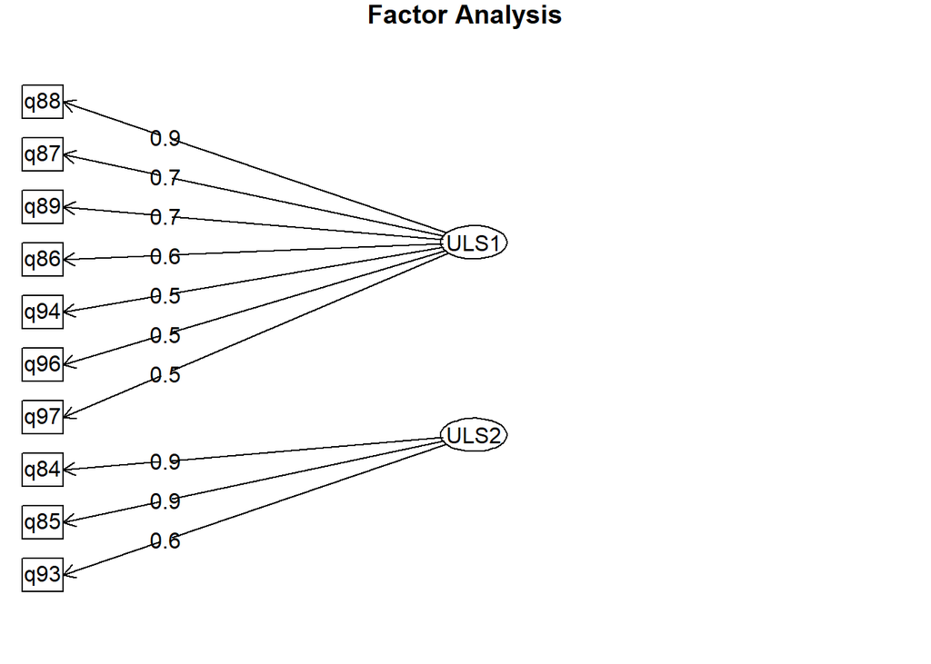

```r
fa.diagram(factor_test_uls)
```

### Factor 1: Tutoring homework

86 I sat with my child while they did their homework.

87 I made myself available when my child had questions about their homework.

88 I helped my child when they were stuck on an assignment.

89 I helped my child prepare for exams by asking questions about the topic, etc.

94 I checked and corrected my child’s homework.

96 I helped my child access other resources (library, art materials, computer lab, etc.).

97 I helped my child practice skills (reading, reviewing, practice problems, etc.).

```r
hw_inv_fa1 <- parent_w1 %>%
  select(q86, q87, q88, q89, q94, q96, q97)

# alpha
alpha(hw_inv_fa1)
```

```
##
## Reliability analysis
## Call: alpha(x = hw_inv_fa1)
##
##   raw_alpha std.alpha G6(smc) average_r S/N   ase mean   sd median_r
##       0.78      0.78    0.78      0.34 3.5 0.035  2.7 0.67     0.33
##
##     95% confidence boundaries
##          lower alpha upper
## Feldt     0.70  0.78  0.84
## Duhachek  0.71  0.78  0.84
##
##  Reliability if an item is dropped:
##     raw_alpha std.alpha G6(smc) average_r S/N alpha se  var.r med.r
## q86      0.74      0.75    0.74      0.33 3.0    0.041 0.0129  0.32
## q87      0.74      0.74    0.73      0.33 2.9    0.041 0.0099  0.33
## q88      0.72      0.72    0.70      0.30 2.6    0.044 0.0069  0.30
## q89      0.74      0.75    0.74      0.33 2.9    0.041 0.0144  0.32
## q94      0.77      0.77    0.76      0.36 3.4    0.037 0.0096  0.33
## q96      0.76      0.76    0.75      0.35 3.2    0.038 0.0126  0.34
## q97      0.76      0.77    0.75      0.35 3.3    0.038 0.0099  0.34
##
##  Item statistics
##      n raw.r std.r r.cor r.drop mean   sd
## q86 94  0.65  0.67  0.60   0.53  2.8 0.91
## q87 93  0.67  0.69  0.63   0.55  3.4 0.88
## q88 92  0.76  0.76  0.74   0.64  3.0 1.03
## q89 94  0.69  0.68  0.59   0.53  2.3 1.20
## q94 92  0.58  0.58  0.47   0.41  2.3 1.04
## q96 94  0.63  0.61  0.52   0.44  2.6 1.10
## q97 94  0.60  0.59  0.49   0.43  2.7 0.97
##
## Non missing response frequency for each item
##        1    2    3    4 miss
## q86 0.11 0.21 0.46 0.22 0.01
## q87 0.06 0.08 0.28 0.58 0.02
## q88 0.13 0.13 0.34 0.40 0.03
## q89 0.37 0.18 0.21 0.23 0.01
## q94 0.30 0.26 0.30 0.13 0.03
## q96 0.23 0.19 0.33 0.24 0.01
## q97 0.17 0.16 0.48 0.19 0.01
```

### Factor 2: checking homework

84 I made sure they had a set time to do their homework.

85 I made sure they had a set place to do their homework.

93 I checked in with my child to make sure they did their homework.

```r
hw_inv_fa2 <- parent_w1 %>%
  select(q84, q85, q93)

# alpha
alpha(hw_inv_fa2)
```

```
##
## Reliability analysis
## Call: alpha(x = hw_inv_fa2)
##
##   raw_alpha std.alpha G6(smc) average_r S/N   ase mean   sd median_r
##       0.74      0.77    0.73      0.53 3.3 0.047  3.6 0.66     0.46
##
##     95% confidence boundaries
##          lower alpha upper
## Feldt     0.64  0.74  0.82
## Duhachek  0.65  0.74  0.84
##
##  Reliability if an item is dropped:
##     raw_alpha std.alpha G6(smc) average_r S/N alpha se var.r med.r
## q84      0.62      0.63    0.46      0.46 1.7    0.075    NA  0.46
## q85      0.52      0.55    0.38      0.38 1.2    0.090    NA  0.38
## q93      0.85      0.85    0.74      0.74 5.7    0.030    NA  0.74
##
##  Item statistics
##      n raw.r std.r r.cor r.drop mean   sd
## q84 92  0.81  0.85  0.79   0.63  3.7 0.67
## q85 94  0.86  0.89  0.84   0.69  3.7 0.76
## q93 94  0.80  0.74  0.50   0.45  3.3 0.97
##
## Non missing response frequency for each item
##        1    2    3    4 miss
## q84 0.03 0.02 0.14 0.80 0.03
## q85 0.05 0.02 0.10 0.83 0.01
## q93 0.09 0.10 0.21 0.61 0.01
```

## Home Structure

In the past three months, I have taken steps to support my child to…

23 … develop a plan for studying and doing homework.

24 … find ways to get involved in school activities.

25 … find ways to get involved in volunteer activities in the community.

26 … set goals for the school year.

27 … meet deadlines.

28 … take on leadership roles in school or the community.

29 … focus on doing their best.

30 … develop a schedule to complete homework and school projects on time.

```r
struct <- parent_w1 %>%
  select(q23, q24, q25, q26, q27, q28, q29, q30)
```

### Kaiser-Meyer-Olkin factor sampling adequacy (> 0.5)

```r
KMO(struct)
```

```
## Kaiser-Meyer-Olkin factor adequacy
## Call: KMO(r = struct)
## Overall MSA =  0.76
## MSA for each item =
##  q23  q24  q25  q26  q27  q28  q29  q30
## 0.71 0.76 0.72 0.81 0.83 0.75 0.78 0.70
```

### Bartlett’s Test of Sphericity (p < .05)

```r
poly <- polychoric(struct)$rho
cortest.bartlett(poly, n = nrow(struct))
```

```
## $chisq
## [1] 531.8145
##
## $p.value
## [1] 0.0000000000000000000000000000000000000000000000000000000000000000000000000000000000000000000001848597
##
## $df
## [1] 28
```

### Poly corr matrix

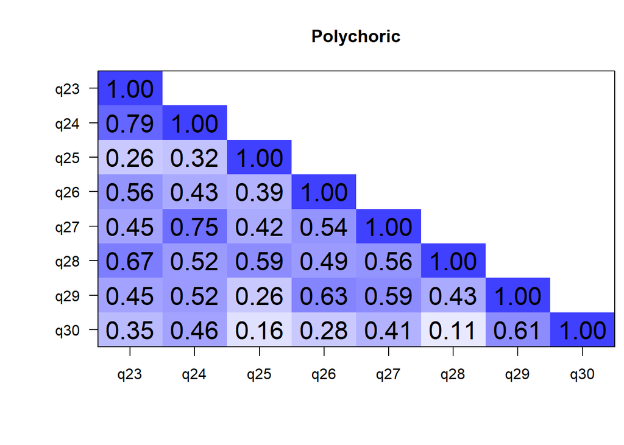

```r
cor.plot(poly, numbers = T, upper = F, main = "Polychoric", show.legend = F)
```

### Scree plot

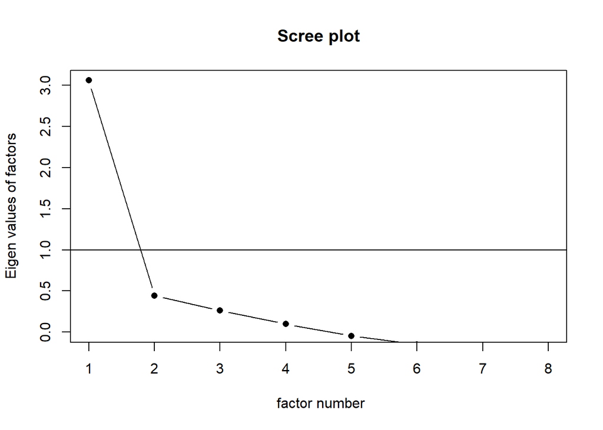

```r
scree(struct, factors = TRUE, pc = FALSE, main = "Scree plot", hline = NULL, add = FALSE)
```

### EFA using ULS - 1 factor

```r
factor_test_uls <- fa(struct, n.obs = 95, rotate = "oblimin", fm = "uls", cor = "poly", nfactors = 1)
factor_test_uls
```

```
## Factor Analysis using method =  uls
## Call: fa(r = struct, nfactors = 1, n.obs = 95, rotate = "oblimin",
##     fm = "uls", cor = "poly")
## Standardized loadings (pattern matrix) based upon correlation matrix
##     ULS1   h2   u2 com
## q23 0.76 0.58 0.42   1
## q24 0.82 0.68 0.32   1
## q25 0.48 0.23 0.77   1
## q26 0.69 0.48 0.52   1
## q27 0.79 0.63 0.37   1
## q28 0.71 0.50 0.50   1
## q29 0.72 0.52 0.48   1
## q30 0.49 0.24 0.76   1
##
##                ULS1
## SS loadings    3.85
## Proportion Var 0.48
##
## Mean item complexity =  1
## Test of the hypothesis that 1 factor is sufficient.
##
## df null model =  28  with the objective function =  5.88 with Chi Square =  531.81
## df of  the model are 20  and the objective function was  2.55
##
## The root mean square of the residuals (RMSR) is  0.11
## The df corrected root mean square of the residuals is  0.13
##
## The harmonic n.obs is  94 with the empirical chi square  67.91  with prob <  0.0000004
## The total n.obs was  95  with Likelihood Chi Square =  228.93  with prob <  0.0000000000000000000000000000000000002
##
## Tucker Lewis Index of factoring reliability =  0.415
## RMSEA index =  0.331  and the 90 % confidence intervals are  0.295 0.373
## BIC =  137.85
## Fit based upon off diagonal values = 0.95
## Measures of factor score adequacy
##                                                   ULS1
## Correlation of (regression) scores with factors   0.95
## Multiple R square of scores with factors          0.90
## Minimum correlation of possible factor scores     0.80
```

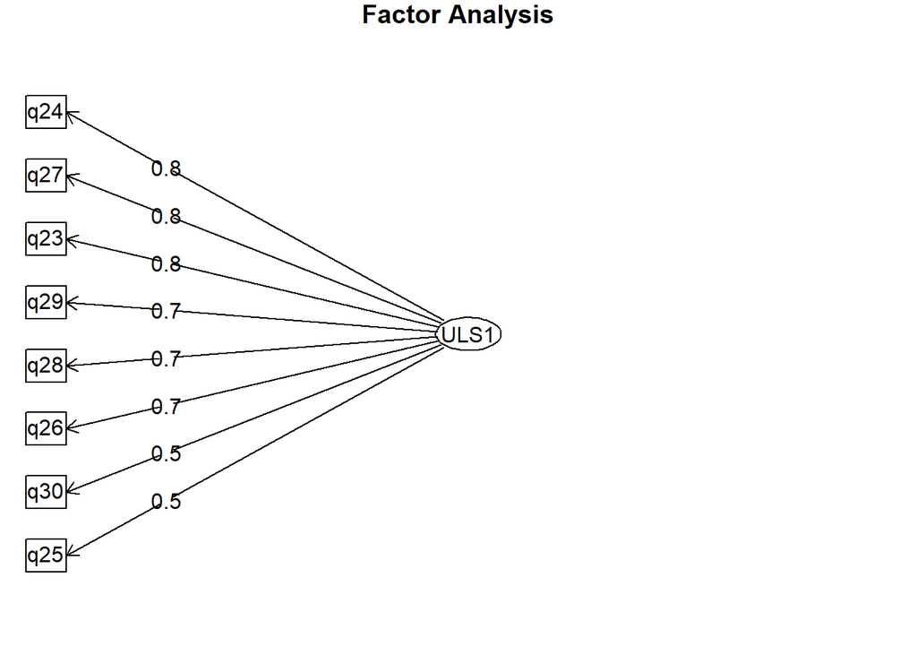

```r
fa.diagram(factor_test_uls)
```

### Factor: Home Structure

```r
alpha(struct)
```

```
##
## Reliability analysis
## Call: alpha(x = struct)
##
##   raw_alpha std.alpha G6(smc) average_r S/N   ase mean   sd median_r
##       0.82      0.82    0.84      0.37 4.6 0.028  2.9 0.43     0.37
##
##     95% confidence boundaries
##          lower alpha upper
## Feldt     0.76  0.82  0.87
## Duhachek  0.77  0.82  0.88
##
##  Reliability if an item is dropped:
##     raw_alpha std.alpha G6(smc) average_r S/N alpha se var.r med.r
## q23      0.80      0.80    0.80      0.36 3.9    0.032 0.018  0.35
## q24      0.78      0.79    0.80      0.34 3.7    0.034 0.018  0.35
## q25      0.82      0.82    0.83      0.40 4.6    0.028 0.017  0.40
## q26      0.80      0.80    0.82      0.37 4.0    0.031 0.022  0.35
## q27      0.79      0.79    0.81      0.35 3.7    0.034 0.020  0.34
## q28      0.79      0.80    0.81      0.36 3.9    0.032 0.017  0.35
## q29      0.80      0.80    0.81      0.36 3.9    0.031 0.021  0.35
## q30      0.83      0.83    0.84      0.41 4.8    0.028 0.013  0.40
##
##  Item statistics
##      n raw.r std.r r.cor r.drop mean   sd
## q23 95  0.69  0.69  0.66   0.57  2.9 0.63
## q24 95  0.76  0.76  0.74   0.66  2.9 0.65
## q25 95  0.57  0.55  0.46   0.41  2.6 0.72
## q26 94  0.66  0.68  0.61   0.55  3.0 0.60
## q27 94  0.75  0.75  0.71   0.65  3.0 0.66
## q28 94  0.72  0.70  0.66   0.59  2.6 0.71
## q29 95  0.68  0.69  0.64   0.57  3.3 0.61
## q30 95  0.50  0.52  0.42   0.35  3.2 0.60
##
## Non missing response frequency for each item
##        1    2    3    4 miss
## q23 0.03 0.14 0.69 0.14 0.00
## q24 0.03 0.18 0.66 0.13 0.00
## q25 0.05 0.37 0.49 0.08 0.00
## q26 0.01 0.13 0.67 0.19 0.01
## q27 0.01 0.19 0.61 0.19 0.01
## q28 0.05 0.39 0.48 0.07 0.01
## q29 0.01 0.05 0.59 0.35 0.00
## q30 0.01 0.07 0.64 0.27 0.00
```

## School Involvement

In general, I make an effort to…

31 … get to know school staff and administrators.

32 … get to know at least one of my child’s teachers.

33 … understand school rules and policies.

34 … inform myself about my rights as a parent.

35 … learn about the educational system in this state.

36 … understand the difference between earning a GED, graduating with a standard high school diploma, an international high school diploma, or an International Baccalaureate (IB) diploma.

37 … get involved in school activities, in the classroom, and/or in other ways (e.g., parent organizations, volunteer work, etc.).

38 … have conversations with other parents to gather information or learn about school resources.

39 … reach out to other parents for support.

40 … understand the pathway to college and career readiness.

41 … attend parent-teacher conferences when available.

```r
scho_inv <- parent_w1 %>%
  select(q31, q32, q33, q34, q35, q36, q37, q38, q39, q40, q41)
```

### Kaiser-Meyer-Olkin factor sampling adequacy (> 0.5)

```r
KMO(scho_inv)
```

```
## Kaiser-Meyer-Olkin factor adequacy
## Call: KMO(r = scho_inv)
## Overall MSA =  0.83
## MSA for each item =
##  q31  q32  q33  q34  q35  q36  q37  q38  q39  q40  q41
## 0.83 0.80 0.82 0.88 0.85 0.86 0.87 0.77 0.84 0.84 0.69
```

### Bartlett’s Test of Sphericity (p < .05)

```r
poly <- polychoric(scho_inv)$rho
cortest.bartlett(poly, n = nrow(scho_inv))
```

```
## $chisq
## [1] 876.1761
##
## $p.value
## [1] 0.0000000000000000000000000000000000000000000000000000000000000000000000000000000000000000000000000000000000000000000000000000000000000000000000000002817739
##
## $df
## [1] 55
```

### Poly corr matrix

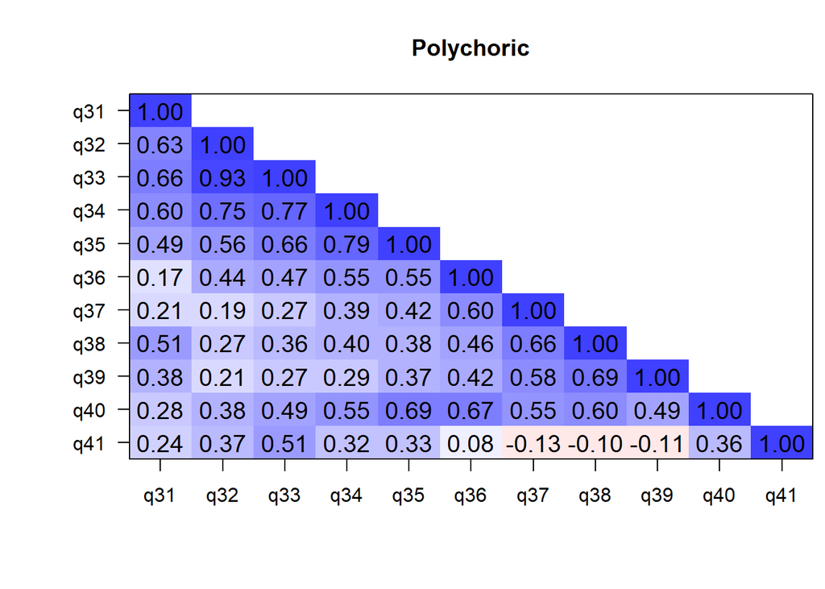

```r
cor.plot(poly, numbers = T, upper = F, main = "Polychoric", show.legend = F)
```

### Scree plot

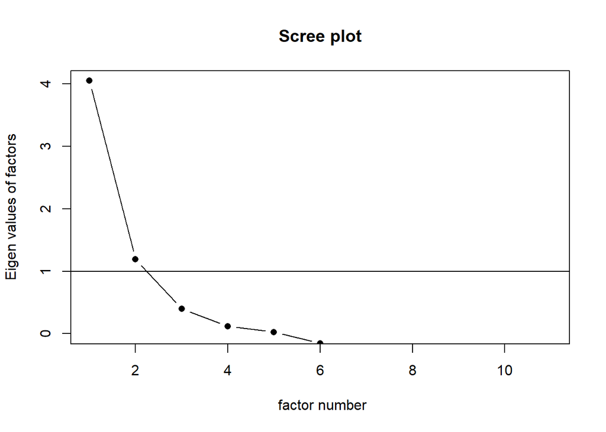

```r
scree(scho_inv, factors = TRUE, pc = FALSE, main = "Scree plot", hline = NULL, add = FALSE)
```

### EFA using ULS 2 factors

```r
factor_test_uls <- fa(scho_inv, n.obs = 95, rotate = "oblimin", fm = "uls", cor = "poly", nfactors = 2)
factor_test_uls
```

```
## Factor Analysis using method =  uls
## Call: fa(r = scho_inv, nfactors = 2, n.obs = 95, rotate = "oblimin",
##     fm = "uls", cor = "poly")
## Standardized loadings (pattern matrix) based upon correlation matrix
##      ULS1  ULS2   h2    u2 com
## q31  0.58  0.14 0.42 0.580 1.1
## q32  0.91 -0.07 0.78 0.224 1.0
## q33  0.98 -0.03 0.94 0.057 1.0
## q34  0.79  0.18 0.77 0.233 1.1
## q35  0.63  0.30 0.64 0.359 1.4
## q36  0.27  0.55 0.50 0.498 1.5
## q37 -0.07  0.86 0.69 0.313 1.0
## q38  0.03  0.81 0.68 0.318 1.0
## q39 -0.04  0.76 0.55 0.450 1.0
## q40  0.35  0.56 0.59 0.407 1.7
## q41  0.61 -0.31 0.32 0.684 1.5
##
##                       ULS1 ULS2
## SS loadings           3.88 2.99
## Proportion Var        0.35 0.27
## Cumulative Var        0.35 0.63
## Proportion Explained  0.56 0.44
## Cumulative Proportion 0.56 1.00
##
##  With factor correlations of
##      ULS1 ULS2
## ULS1 1.00 0.41
## ULS2 0.41 1.00
##
## Mean item complexity =  1.2
## Test of the hypothesis that 2 factors are sufficient.
##
## df null model =  55  with the objective function =  9.79 with Chi Square =  876.18
## df of  the model are 34  and the objective function was  2.65
##
## The root mean square of the residuals (RMSR) is  0.08
## The df corrected root mean square of the residuals is  0.1
##
## The harmonic n.obs is  94 with the empirical chi square  61.07  with prob <  0.003
## The total n.obs was  95  with Likelihood Chi Square =  233.47  with prob <  0.00000000000000000000000000000013
##
## Tucker Lewis Index of factoring reliability =  0.601
## RMSEA index =  0.248  and the 90 % confidence intervals are  0.22 0.281
## BIC =  78.64
## Fit based upon off diagonal values = 0.98
```

### Removing crossloading items

```r
scho_inv <- parent_w1 %>%
  select(q31, q32, q33, q34, q36, q37, q38, q39) # removed 35, 40, 41
```

### Kaiser-Meyer-Olkin factor sampling adequacy (> 0.5)

```r
KMO(scho_inv)
```

```
## Kaiser-Meyer-Olkin factor adequacy
## Call: KMO(r = scho_inv)
## Overall MSA =  0.8
## MSA for each item =
##  q31  q32  q33  q34  q36  q37  q38  q39
## 0.82 0.77 0.78 0.88 0.81 0.80 0.76 0.79
```

### Bartlett’s Test of Sphericity (p < .05)

```r
poly <- polychoric(scho_inv)$rho
cortest.bartlett(poly, n = nrow(scho_inv))
```

```
## $chisq
## [1] 559.6575
##
## $p.value
## [1] 0.0000000000000000000000000000000000000000000000000000000000000000000000000000000000000000000000000003219755
##
## $df
## [1] 28
```

### Poly corr matrix

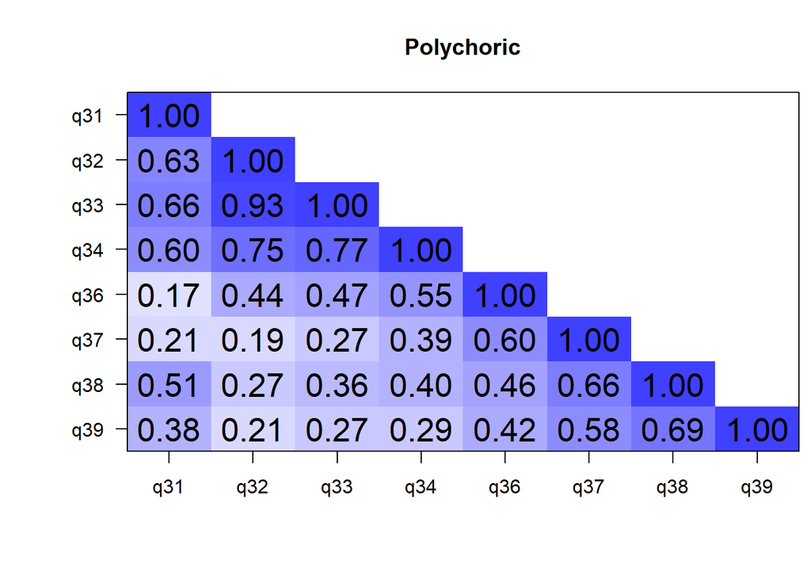

```r
cor.plot(poly, numbers = T, upper = F, main = "Polychoric", show.legend = F)
```

### Scree plot

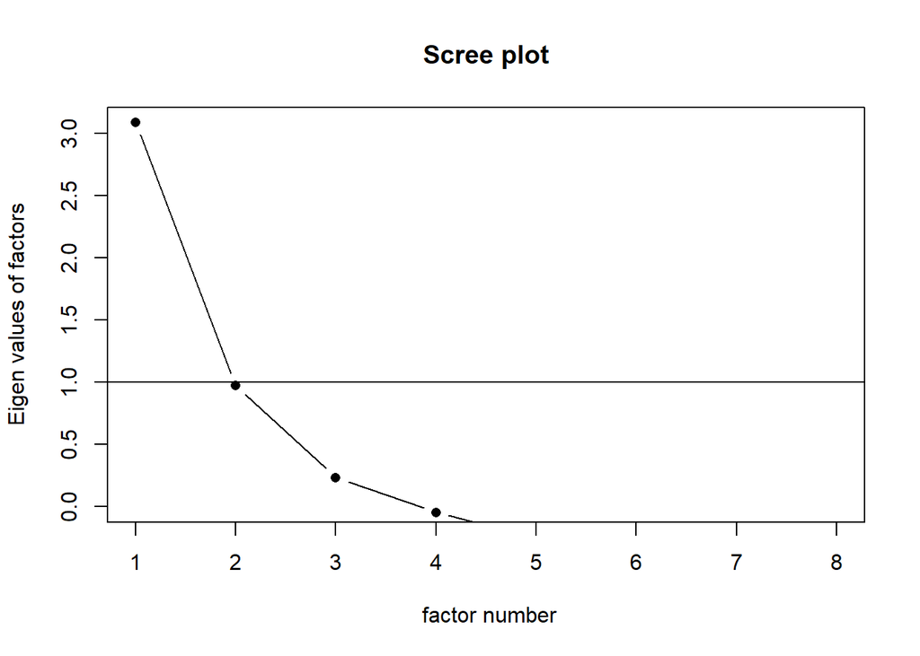

```r
scree(scho_inv, factors = TRUE, pc = FALSE, main = "Scree plot", hline = NULL, add = FALSE)
```

### 2nd EFA iteration

```r
factor_test_uls <- fa(scho_inv, n.obs = 95, rotate = "oblimin", fm = "uls", cor = "poly", nfactors = 2)
factor_test_uls
```

```
## Factor Analysis using method =  uls
## Call: fa(r = scho_inv, nfactors = 2, n.obs = 95, rotate = "oblimin",
##     fm = "uls", cor = "poly")
## Standardized loadings (pattern matrix) based upon correlation matrix
##      ULS1  ULS2   h2    u2 com
## q31  0.60  0.17 0.47 0.533 1.2
## q32  1.00 -0.10 0.93 0.071 1.0
## q33  0.96  0.00 0.93 0.071 1.0
## q34  0.75  0.19 0.70 0.300 1.1
## q36  0.26  0.50 0.43 0.575 1.5
## q37 -0.06  0.84 0.67 0.327 1.0
## q38  0.05  0.82 0.71 0.285 1.0
## q39 -0.02  0.76 0.57 0.431 1.0
##
##                       ULS1 ULS2
## SS loadings           3.01 2.39
## Proportion Var        0.38 0.30
## Cumulative Var        0.38 0.68
## Proportion Explained  0.56 0.44
## Cumulative Proportion 0.56 1.00
##
##  With factor correlations of
##      ULS1 ULS2
## ULS1  1.0  0.4
## ULS2  0.4  1.0
##
## Mean item complexity =  1.1
## Test of the hypothesis that 2 factors are sufficient.
##
## df null model =  28  with the objective function =  6.18 with Chi Square =  559.66
## df of  the model are 13  and the objective function was  0.64
##
## The root mean square of the residuals (RMSR) is  0.07
## The df corrected root mean square of the residuals is  0.1
##
## The harmonic n.obs is  94 with the empirical chi square  23.16  with prob <  0.04
## The total n.obs was  95  with Likelihood Chi Square =  56.68  with prob <  0.0000002
##
## Tucker Lewis Index of factoring reliability =  0.82
## RMSEA index =  0.188  and the 90 % confidence intervals are  0.14 0.241
## BIC =  -2.52
## Fit based upon off diagonal values = 0.98
## Measures of factor score adequacy
##                                                   ULS1 ULS2
## Correlation of (regression) scores with factors   0.99 0.93
## Multiple R square of scores with factors          0.97 0.87
## Minimum correlation of possible factor scores     0.95 0.75
```

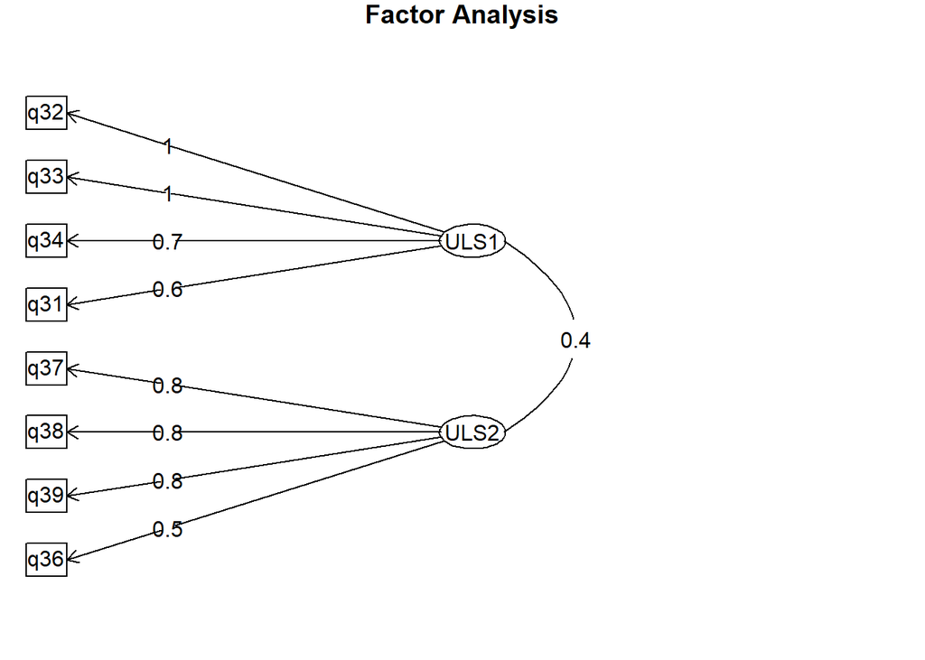

```r
fa.diagram(factor_test_uls)
```

### Factor 1: School familiarity

31 … get to know school staff and administrators.

32 … get to know at least one of my child’s teachers.

33 … understand school rules and policies.

34 … inform myself about my rights as a parent.

```r
scho_inv_fa1 <- parent_w1 %>%
  select(q31, q32, q33, q34)

# alpha
alpha(scho_inv_fa1)
```

```
##
## Reliability analysis
## Call: alpha(x = scho_inv_fa1)
##
##   raw_alpha std.alpha G6(smc) average_r S/N   ase mean   sd median_r
##       0.85      0.85    0.82      0.59 5.7 0.026    3 0.52     0.57
##
##     95% confidence boundaries
##          lower alpha upper
## Feldt     0.79  0.85  0.89
## Duhachek  0.80  0.85  0.90
##
##  Reliability if an item is dropped:
##     raw_alpha std.alpha G6(smc) average_r S/N alpha se  var.r med.r
## q31      0.84      0.85    0.80      0.65 5.5    0.029 0.0122  0.60
## q32      0.79      0.79    0.72      0.55 3.7    0.038 0.0033  0.56
## q33      0.77      0.77    0.69      0.53 3.4    0.041 0.0016  0.53
## q34      0.83      0.83    0.79      0.62 5.0    0.031 0.0174  0.56
##
##  Item statistics
##      n raw.r std.r r.cor r.drop mean   sd
## q31 94  0.78  0.78  0.65   0.60  2.8 0.63
## q32 95  0.86  0.86  0.83   0.75  3.0 0.58
## q33 95  0.88  0.88  0.86   0.77  3.0 0.63
## q34 95  0.81  0.80  0.69   0.64  2.9 0.68
##
## Non missing response frequency for each item
##        1    2    3    4 miss
## q31 0.03 0.20 0.67 0.10 0.01
## q32 0.02 0.09 0.73 0.16 0.00
## q33 0.02 0.12 0.66 0.20 0.00
## q34 0.03 0.18 0.63 0.16 0.00
```

### Factor 2: Proactive school enagagement

36 … understand the difference between earning a GED, graduating with a standard high school diploma, an international high school diploma, or an International Baccalaureate (IB) diploma.

37 … get involved in school activities, in the classroom, and/or in other ways (e.g., parent organizations, volunteer work, etc.).

38 … have conversations with other parents to gather information or learn about school resources.

39 … reach out to other parents for support.

```r
scho_inv_fa2 <- parent_w1 %>%
  select(q36, q37, q38, q39)

# alpha
alpha(scho_inv_fa2)
```

```
##
## Reliability analysis
## Call: alpha(x = scho_inv_fa2)
##
##   raw_alpha std.alpha G6(smc) average_r S/N   ase mean   sd median_r
##       0.79      0.78    0.75      0.48 3.6 0.036  2.6 0.53     0.48
##
##     95% confidence boundaries
##          lower alpha upper
## Feldt     0.71  0.79  0.85
## Duhachek  0.72  0.79  0.86
##
##  Reliability if an item is dropped:
##     raw_alpha std.alpha G6(smc) average_r S/N alpha se  var.r med.r
## q36      0.79      0.79    0.72      0.55 3.7    0.037 0.0068  0.55
## q37      0.72      0.71    0.65      0.45 2.5    0.051 0.0268  0.38
## q38      0.69      0.69    0.61      0.43 2.3    0.055 0.0063  0.48
## q39      0.72      0.73    0.65      0.47 2.6    0.049 0.0072  0.48
##
##  Item statistics
##      n raw.r std.r r.cor r.drop mean   sd
## q36 95  0.70  0.70  0.53   0.47  2.9 0.65
## q37 94  0.80  0.80  0.70   0.63  2.6 0.66
## q38 94  0.83  0.82  0.76   0.67  2.5 0.71
## q39 95  0.79  0.79  0.70   0.61  2.3 0.68
##
## Non missing response frequency for each item
##        1    2    3    4 miss
## q36 0.02 0.18 0.64 0.16 0.00
## q37 0.01 0.48 0.43 0.09 0.01
## q38 0.07 0.45 0.43 0.05 0.01
## q39 0.08 0.54 0.35 0.03 0.00
```

## School belonging

As a parent at this school, I feel…

47 … like part of a community with school staff and other parents.

48 … treated with respect, knowing that my opinions matter.

49 … comfortable asking for a translator and for materials in Spanish if I need them.

50 … able to talk to teachers or administrators about major concerns related to my child.

51 … committed to creating a successful environment for all children.

52 … happy that my child attends this school.

53 … welcomed at my child’s school.

```r
belong <- parent_w1 %>%
  select(q47, q48, q49, q50, q51, q52, q53)
```

### Kaiser-Meyer-Olkin factor sampling adequacy (> 0.5)

```r
KMO(belong)
```

```
## Kaiser-Meyer-Olkin factor adequacy
## Call: KMO(r = belong)
## Overall MSA =  0.83
## MSA for each item =
##  q47  q48  q49  q50  q51  q52  q53
## 0.77 0.85 0.85 0.83 0.76 0.82 0.84
```

### Bartlett’s Test of Sphericity (p < .05)

```r
poly <- polychoric(belong)$rho
cortest.bartlett(poly, n = nrow(belong))
```

```
## $chisq
## [1] 686.0725
##
## $p.value
## [1] 0.00000000000000000000000000000000000000000000000000000000000000000000000000000000000000000000000000000000000000000000000000000000001160902
##
## $df
## [1] 21
```

### Poly corr matrix

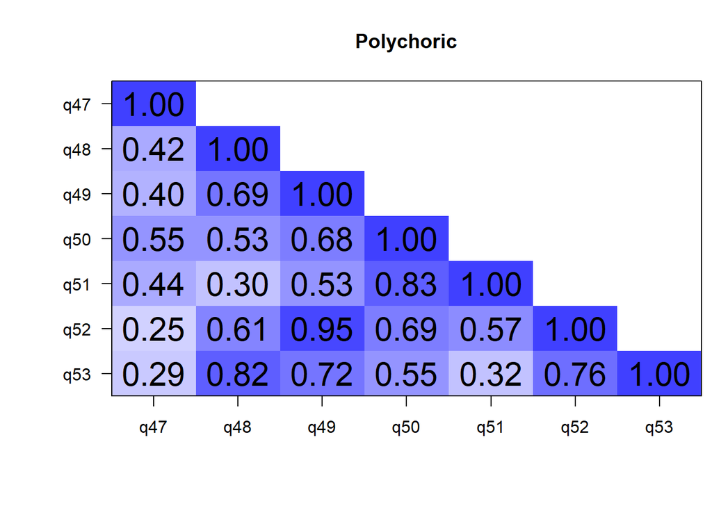

```r
cor.plot(poly, numbers = T, upper = F, main = "Polychoric", show.legend = F)
```

### Scree plot

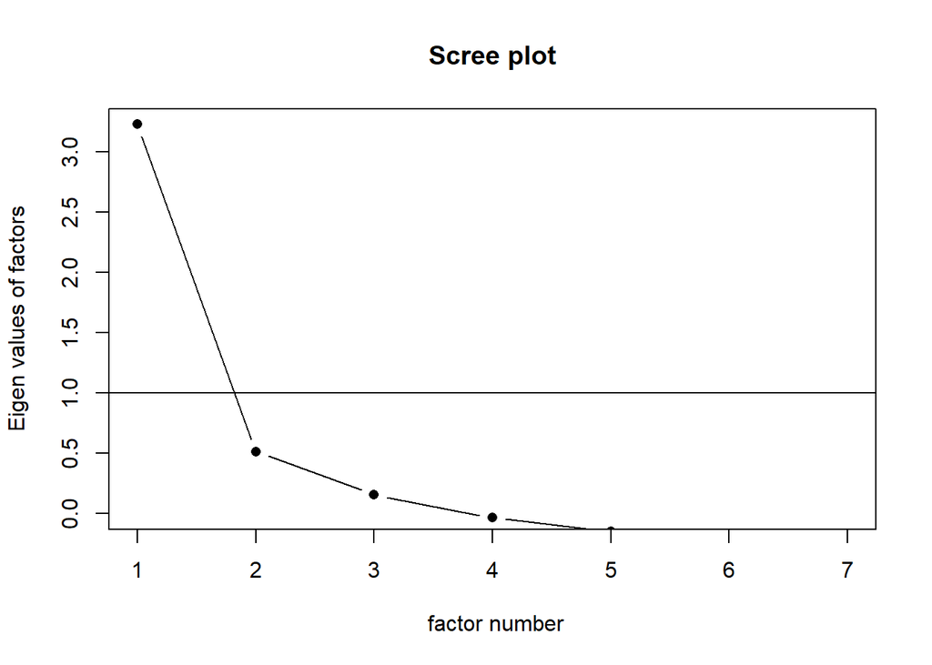

```r
scree(belong, factors = TRUE, pc = FALSE, main = "Scree plot", hline = NULL, add = FALSE)
```

### EFA using ULS 1 factor

```r
factor_test_uls <- fa(belong, n.obs = 95, rotate = "oblimin", fm = "uls", cor = "poly", nfactors = 1)
factor_test_uls
```

```
## Factor Analysis using method =  uls
## Call: fa(r = belong, nfactors = 1, n.obs = 95, rotate = "oblimin",
##     fm = "uls", cor = "poly")
## Standardized loadings (pattern matrix) based upon correlation matrix
##     ULS1   h2   u2 com
## q47 0.48 0.23 0.77   1
## q48 0.74 0.55 0.45   1
## q49 0.92 0.84 0.16   1
## q50 0.83 0.69 0.31   1
## q51 0.64 0.40 0.60   1
## q52 0.89 0.80 0.20   1
## q53 0.78 0.61 0.39   1
##
##                ULS1
## SS loadings    4.13
## Proportion Var 0.59
##
## Mean item complexity =  1
## Test of the hypothesis that 1 factor is sufficient.
##
## df null model =  21  with the objective function =  7.55 with Chi Square =  686.07
## df of  the model are 14  and the objective function was  3.06
##
## The root mean square of the residuals (RMSR) is  0.13
## The df corrected root mean square of the residuals is  0.16
##
## The harmonic n.obs is  93 with the empirical chi square  63.93  with prob <  0.000000024
## The total n.obs was  95  with Likelihood Chi Square =  276.15  with prob <  0.000000000000000000000000000000000000000000000000011
##
## Tucker Lewis Index of factoring reliability =  0.404
## RMSEA index =  0.444  and the 90 % confidence intervals are  0.401 0.493
## BIC =  212.4
## Fit based upon off diagonal values = 0.95
## Measures of factor score adequacy
##                                                   ULS1
## Correlation of (regression) scores with factors   0.97
## Multiple R square of scores with factors          0.94
## Minimum correlation of possible factor scores     0.89
```

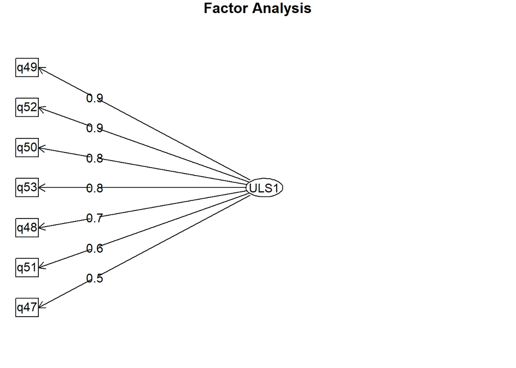

```r
fa.diagram(factor_test_uls)
```

### Factor: school belonging

```r
alpha(belong)
```

```
##
## Reliability analysis
## Call: alpha(x = belong)
##
##   raw_alpha std.alpha G6(smc) average_r S/N   ase mean   sd median_r
##       0.83      0.84    0.86      0.44 5.4 0.027  3.1 0.37     0.42
##
##     95% confidence boundaries
##          lower alpha upper
## Feldt     0.78  0.83  0.88
## Duhachek  0.78  0.83  0.89
##
##  Reliability if an item is dropped:
##     raw_alpha std.alpha G6(smc) average_r S/N alpha se var.r med.r
## q47      0.85      0.86    0.86      0.50 5.9    0.024 0.023  0.53
## q48      0.81      0.83    0.84      0.44 4.8    0.031 0.033  0.42
## q49      0.79      0.80    0.82      0.40 4.0    0.034 0.026  0.41
## q50      0.79      0.81    0.82      0.41 4.1    0.034 0.035  0.39
## q51      0.82      0.84    0.84      0.46 5.2    0.029 0.030  0.47
## q52      0.80      0.81    0.82      0.41 4.2    0.033 0.024  0.41
## q53      0.80      0.82    0.83      0.42 4.4    0.032 0.025  0.41
##
##  Item statistics
##      n raw.r std.r r.cor r.drop mean   sd
## q47 94  0.58  0.54  0.42   0.38  2.8 0.63
## q48 94  0.71  0.70  0.63   0.57  3.0 0.55
## q49 94  0.80  0.83  0.81   0.74  3.2 0.45
## q50 94  0.80  0.80  0.77   0.71  3.1 0.48
## q51 92  0.64  0.63  0.56   0.49  3.0 0.51
## q52 95  0.77  0.78  0.76   0.66  3.3 0.49
## q53 95  0.74  0.75  0.72   0.63  3.2 0.49
##
## Non missing response frequency for each item
##        1    2    3    4 miss
## q47 0.03 0.20 0.67 0.10 0.01
## q48 0.01 0.12 0.73 0.14 0.01
## q49 0.00 0.02 0.77 0.21 0.01
## q50 0.01 0.03 0.79 0.17 0.01
## q51 0.01 0.08 0.77 0.14 0.03
## q52 0.00 0.02 0.68 0.29 0.00
## q53 0.00 0.05 0.74 0.21 0.00
```

## School endorsement

As a parent at this school, I am confident that…

54 … this school is a good place for my child.

55 … my child’s school staff are doing good things for them.

56 … people at my child’s school are trustworthy.

57 … my child’s school does a good job preparing students for their futures.

```r
endorse <- parent_w1 %>%
  select(q54, q55, q56, q57)
```

### Kaiser-Meyer-Olkin factor sampling adequacy (> 0.5)

```r
KMO(endorse)
```

```
## Kaiser-Meyer-Olkin factor adequacy
## Call: KMO(r = endorse)
## Overall MSA =  0.81
## MSA for each item =
##  q54  q55  q56  q57
## 0.89 0.77 0.81 0.82
```

### Bartlett’s Test of Sphericity (p < .05)

```r
poly <- polychoric(endorse)$rho
cortest.bartlett(poly, n = nrow(endorse))
```

```
## $chisq
## [1] 558.1087
##
## $p.value
## [1] 0.000000000000000000000000000000000000000000000000000000000000000000000000000000000000000000000000000000000000000000002521747
##
## $df
## [1] 6
```

### Poly corr matrix

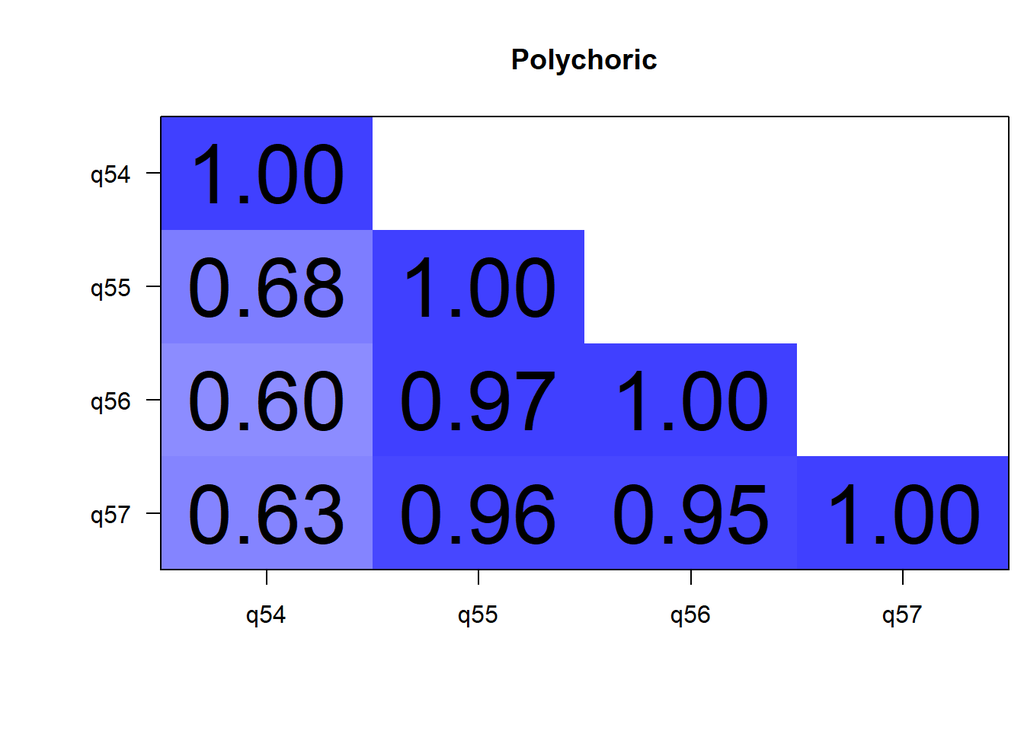

```r
cor.plot(poly, numbers = T, upper = F, main = "Polychoric", show.legend = F)
```

### Scree plot

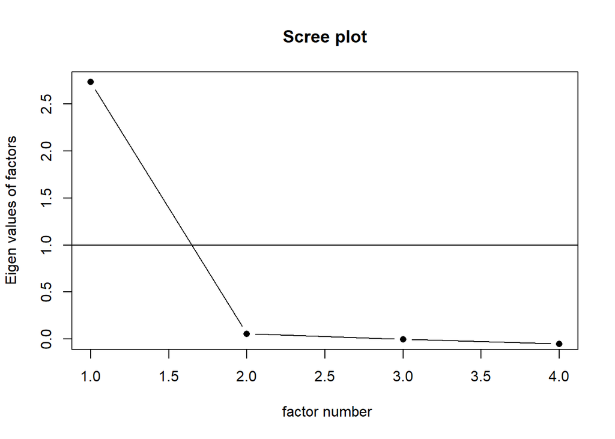

```r
scree(endorse, factors = TRUE, pc = FALSE, main = "Scree plot", hline = NULL, add = FALSE)
```

### EFA using ULS 1 factor

```r
factor_test_uls <- fa(endorse, n.obs = 95, rotate = "oblimin", fm = "uls", cor = "poly", nfactors = 1)
factor_test_uls
```

```
## Factor Analysis using method =  uls
## Call: fa(r = endorse, nfactors = 1, n.obs = 95, rotate = "oblimin",
##     fm = "uls", cor = "poly")
## Standardized loadings (pattern matrix) based upon correlation matrix
##     ULS1   h2      u2 com
## q54 0.65 0.42  0.5776   1
## q55 1.00 1.00 -0.0032   1
## q56 0.96 0.93  0.0740   1
## q57 0.97 0.94  0.0572   1
##
##                ULS1
## SS loadings    3.29
## Proportion Var 0.82
##
## Mean item complexity =  1
## Test of the hypothesis that 1 factor is sufficient.
##
## df null model =  6  with the objective function =  6.08 with Chi Square =  558.11
## df of  the model are 2  and the objective function was  0.32
##
## The root mean square of the residuals (RMSR) is  0.02
## The df corrected root mean square of the residuals is  0.03
##
## The harmonic n.obs is  94 with the empirical chi square  0.36  with prob <  0.84
## The total n.obs was  95  with Likelihood Chi Square =  29.06  with prob <  0.00000049
##
## Tucker Lewis Index of factoring reliability =  0.852
## RMSEA index =  0.377  and the 90 % confidence intervals are  0.265 0.507
## BIC =  19.95
## Fit based upon off diagonal values = 1
```

### Removing item Ultra-Heywood case

```r
endorse <- parent_w1 %>%
  select(q54, q56, q57) # removed 55
```

### Kaiser-Meyer-Olkin factor sampling adequacy (> 0.5)

```r
KMO(endorse)
```

```
## Kaiser-Meyer-Olkin factor adequacy
## Call: KMO(r = endorse)
## Overall MSA =  0.65
## MSA for each item =
##  q54  q56  q57
## 0.85 0.61 0.60
```

### Bartlett’s Test of Sphericity (p < .05)

```r
poly <- polychoric(endorse)$rho
cortest.bartlett(poly, n = nrow(endorse))
```

```
## $chisq
## [1] 259.6424
##
## $p.value
## [1] 0.00000000000000000000000000000000000000000000000000000005372192
##
## $df
## [1] 3
```

### Poly corr matrix

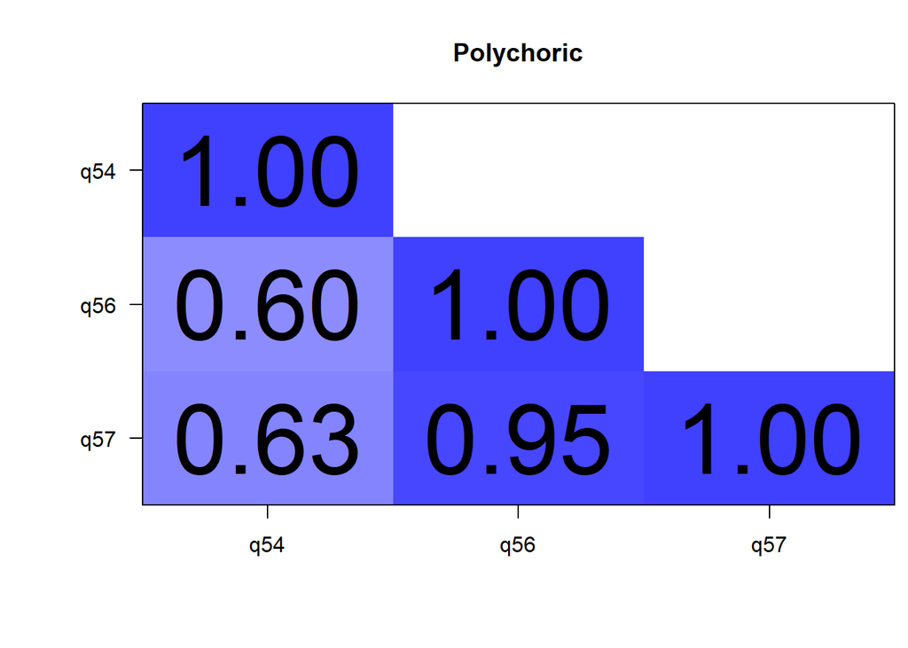

```r
cor.plot(poly, numbers = T, upper = F, main = "Polychoric", show.legend = F)
```

### Scree plot

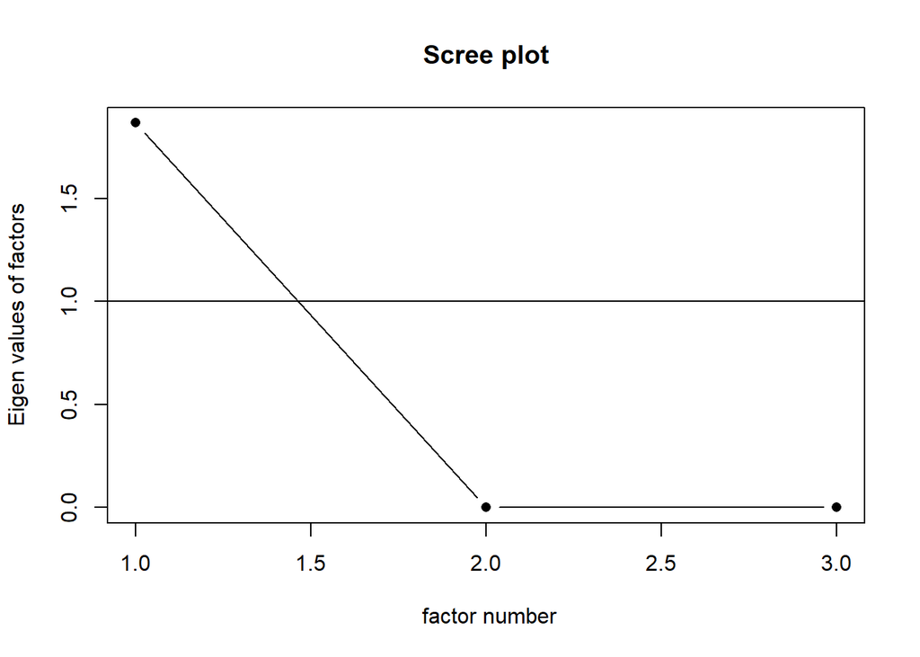

```r
scree(endorse, factors = TRUE, pc = FALSE, main = "Scree plot", hline = NULL, add = FALSE)
```

### 2nd EFA iteration

```r
factor_test_uls <- fa(endorse, n.obs = 95, rotate = "oblimin", fm = "uls", cor = "poly", nfactors = 1)
factor_test_uls
```

```
## Factor Analysis using method =  uls
## Call: fa(r = endorse, nfactors = 1, n.obs = 95, rotate = "oblimin",
##     fm = "uls", cor = "poly")
## Standardized loadings (pattern matrix) based upon correlation matrix
##     ULS1  h2     u2 com
## q54 0.63 0.4 0.6030   1
## q56 0.95 0.9 0.0961   1
## q57 1.00 1.0 0.0041   1
##
##                ULS1
## SS loadings    2.30
## Proportion Var 0.77
##
## Mean item complexity =  1
## Test of the hypothesis that 1 factor is sufficient.
##
## df null model =  3  with the objective function =  2.82 with Chi Square =  259.64
## df of  the model are 0  and the objective function was  0
##
## The root mean square of the residuals (RMSR) is  0
## The df corrected root mean square of the residuals is  NA
##
## The harmonic n.obs is  93 with the empirical chi square  0  with prob <  NA
## The total n.obs was  95  with Likelihood Chi Square =  0.01  with prob <  NA
##
## Tucker Lewis Index of factoring reliability =  -Inf
## Fit based upon off diagonal values = 1
## Measures of factor score adequacy
##                                                   ULS1
## Correlation of (regression) scores with factors   1.00
## Multiple R square of scores with factors          1.00
## Minimum correlation of possible factor scores     0.99
```

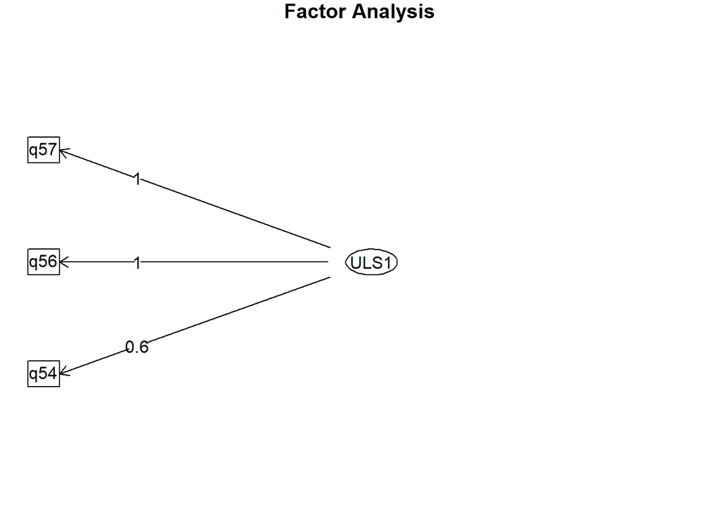

```r
fa.diagram(factor_test_uls)
```

### Factor: school endorsement

```r
alpha(endorse)
```

```
##
## Reliability analysis
## Call: alpha(x = endorse)
##
##   raw_alpha std.alpha G6(smc) average_r S/N   ase mean   sd median_r
##       0.79      0.81    0.77      0.58 4.2 0.038  3.2 0.41     0.51
##
##     95% confidence boundaries
##          lower alpha upper
## Feldt     0.71  0.79  0.86
## Duhachek  0.72  0.79  0.87
##
##  Reliability if an item is dropped:
##     raw_alpha std.alpha G6(smc) average_r S/N alpha se var.r med.r
## q54      0.87      0.88    0.78      0.78 7.0    0.026    NA  0.78
## q56      0.66      0.67    0.51      0.51 2.1    0.068    NA  0.51
## q57      0.63      0.64    0.47      0.47 1.8    0.073    NA  0.47
##
##  Item statistics
##      n raw.r std.r r.cor r.drop mean   sd
## q54 95  0.81  0.77  0.56   0.52  3.2 0.55
## q56 93  0.86  0.88  0.83   0.70  3.2 0.44
## q57 94  0.88  0.90  0.86   0.73  3.2 0.45
##
## Non missing response frequency for each item
##        1    2    3    4 miss
## q54 0.01 0.04 0.71 0.24 0.00
## q56 0.00 0.03 0.78 0.18 0.02
## q57 0.00 0.03 0.78 0.19 0.01
```

## Parent-teacher relationship

At this school, I feel there is at least one teacher…

64 … who cares about my child.

65 … who is interested in getting to know me.

66 … with whom I feel comfortable talking about my child.

67 … from whom I can ask questions or make suggestions about my child.

```r
pt_rel <- parent_w1 %>%
  select(q64, q65, q66, q67)
```

### Kaiser-Meyer-Olkin factor sampling adequacy (> 0.5)

```r
KMO(pt_rel)
```

```
## Kaiser-Meyer-Olkin factor adequacy
## Call: KMO(r = pt_rel)
## Overall MSA =  0.77
## MSA for each item =
##  q64  q65  q66  q67
## 0.88 0.90 0.71 0.71
```

### Bartlett’s Test of Sphericity (p < .05)

```r
poly <- polychoric(pt_rel)$rho
cortest.bartlett(poly, n = nrow(pt_rel))
```

```
## $chisq
## [1] 2291.653
##
## $p.value
## [1] 0
##
## $df
## [1] 6
```

### Poly corr matrix

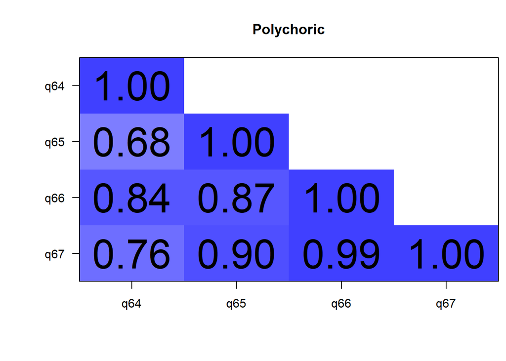

```r
cor.plot(poly, numbers = T, upper = F, main = "Polychoric", show.legend = F)
```

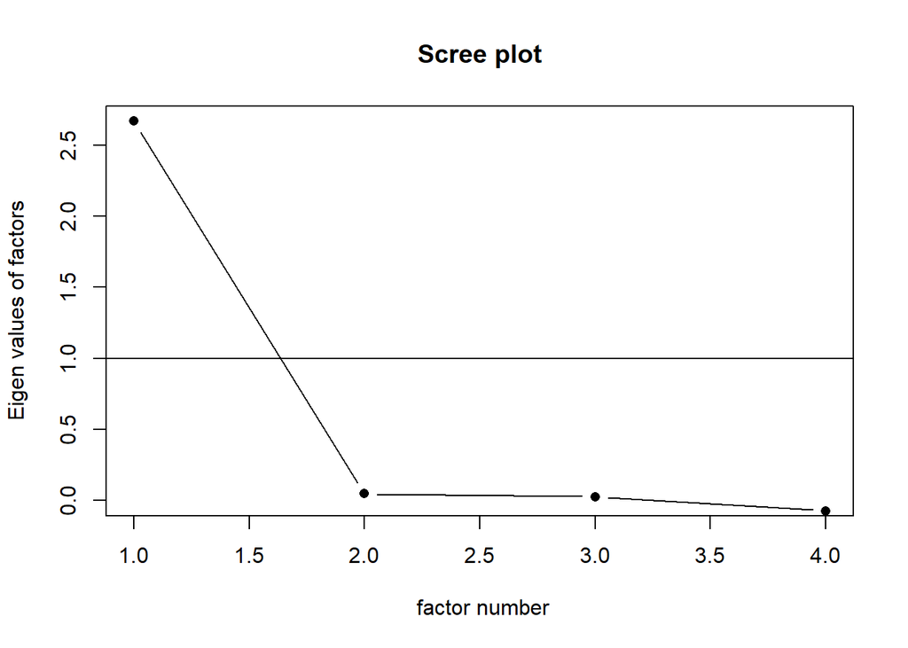

```r
scree(pt_rel, factors = TRUE, pc = FALSE, main = "Scree plot", hline = NULL, add = FALSE)
```

## EFA using ULS

```r
factor_test_uls <- fa(pt_rel, n.obs = 95, rotate = "oblimin", fm = "uls", cor = "poly", nfactors = 1)
factor_test_uls
```

```
## Factor Analysis using method =  uls
## Call: fa(r = pt_rel, nfactors = 1, n.obs = 95, rotate = "oblimin",
##     fm = "uls", cor = "poly")
## Standardized loadings (pattern matrix) based upon correlation matrix
##     ULS1   h2     u2 com
## q64 0.79 0.63  0.370   1
## q65 0.88 0.78  0.225   1
## q66 1.01 1.01 -0.011   1
## q67 0.99 0.98  0.017   1
##
##                ULS1
## SS loadings    3.40
## Proportion Var 0.85
##
## Mean item complexity =  1
## Test of the hypothesis that 1 factor is sufficient.
##
## df null model =  6  with the objective function =  24.95 with Chi Square =  2291.65
## df of  the model are 2  and the objective function was  20.18
##
## The root mean square of the residuals (RMSR) is  0.03
## The df corrected root mean square of the residuals is  0.05
##
## The harmonic n.obs is  92 with the empirical chi square  0.83  with prob <  0.66
## The total n.obs was  95  with Likelihood Chi Square =  1839.35  with prob <  0
##
## Tucker Lewis Index of factoring reliability =  -1.429
## RMSEA index =  3.11  and the 90 % confidence intervals are  3.007 3.247
## BIC =  1830.24
## Fit based upon off diagonal values = 1
```

### Removing item Ultra-Heywood case

```r
pt_rel <- parent_w1 %>%
  select(q64, q65, q67) # removed 66
```

### 2nd EFA iteration

```r
factor_test_uls <- fa(pt_rel, n.obs = 95, rotate = "oblimin", fm = "uls", cor = "poly", nfactors = 1)
factor_test_uls # it only works with ml (jaime suggest removing the scale and adding it as a limitation and future directions)
```

```
## Factor Analysis using method =  uls
## Call: fa(r = pt_rel, nfactors = 1, n.obs = 95, rotate = "oblimin",
##     fm = "uls", cor = "poly")
## Standardized loadings (pattern matrix) based upon correlation matrix
##     ULS1   h2      u2 com
## q64 0.76 0.57  0.4290   1
## q65 0.90 0.81  0.1861   1
## q67 1.00 1.00 -0.0028   1
##
##                ULS1
## SS loadings    2.39
## Proportion Var 0.80
##
## Mean item complexity =  1
## Test of the hypothesis that 1 factor is sufficient.
##
## df null model =  3  with the objective function =  2.61 with Chi Square =  240.55
## df of  the model are 0  and the objective function was  0
##
## The root mean square of the residuals (RMSR) is  0.01
## The df corrected root mean square of the residuals is  NA
##
## The harmonic n.obs is  91 with the empirical chi square  0.01  with prob <  NA
## The total n.obs was  95  with Likelihood Chi Square =  0.36  with prob <  NA
##
## Tucker Lewis Index of factoring reliability =  -Inf
## Fit based upon off diagonal values = 1
```

Another Ultra-Heywood case. Removing the item would yield a factor with 2 items. Conclusion: EFA not possible with this scale.

```r
pt_rel <- parent_w1 %>%
  select(q64, q65, q66, q67)

alpha(pt_rel)
```

```
##
## Reliability analysis
## Call: alpha(x = pt_rel)
##
##   raw_alpha std.alpha G6(smc) average_r S/N   ase mean   sd median_r
##       0.87      0.88    0.87      0.64 7.2 0.021  3.1 0.46     0.64
##
##     95% confidence boundaries
##          lower alpha upper
## Feldt     0.83  0.87  0.91
## Duhachek  0.83  0.87  0.91
##
##  Reliability if an item is dropped:
##     raw_alpha std.alpha G6(smc) average_r S/N alpha se  var.r med.r
## q64      0.89      0.90    0.88      0.75 9.2    0.021 0.0109  0.70
## q65      0.85      0.85    0.84      0.66 5.8    0.026 0.0356  0.59
## q66      0.80      0.80    0.74      0.57 4.0    0.035 0.0133  0.52
## q67      0.80      0.81    0.76      0.59 4.3    0.034 0.0091  0.59
##
##  Item statistics
##      n raw.r std.r r.cor r.drop mean   sd
## q64 94  0.74  0.76  0.62   0.59  3.2 0.46
## q65 90  0.85  0.84  0.76   0.70  3.0 0.56
## q66 94  0.93  0.92  0.92   0.83  3.1 0.58
## q67 93  0.91  0.90  0.90   0.82  3.1 0.50
##
## Non missing response frequency for each item
##        2    3    4 miss
## q64 0.02 0.74 0.23 0.01
## q65 0.14 0.69 0.17 0.05
## q66 0.14 0.66 0.20 0.01
## q67 0.10 0.75 0.15 0.02
```